# Figure S1 — Cross-species enrichment of P11 MIA+Hx (dual-hit) insult-unique signature

Panel A: CAMERA heatmap · Panel B: limma barcode · Panel C: gprofiler dotplot

Kratimenos Lab

2026-06-01

# 1. Overview

This report assembles **Figure S1** for the manuscript: a three-panel cross-species summary of the **P11 MIA+Hx (dual-hit) insult-unique transcriptional signature** and how it relates to the human preterm-vs-term ranking.

- **Panel A** — Heatmap of CAMERA pre-ranked enrichment of all six P11 insult-unique signatures (MIA / Hx / MIA+Hx × up / down) against the human PC-vs-CC ranking. Shows that the **MIA+Hx (dual-hit) signature is the only one to reach significance** (FDR = 0.0032 in both directions); MIA-only and Hx-only signatures are not significant (FDR = 0.071).
- **Panel B** — Barcode plot of the MIA+Hx insult-unique signature projected onto the human Wald-statistic ranking, with `limma::barcodeplot` Enrichment / Weight panels. Provides the gene-level support for the Panel-A heatmap result.
- **Panel C** — `gprofiler2::gost` over-representation of the down-regulated MIA+Hx insult-unique orthologs against curated pathway sources (GO BP and Reactome). Identifies the **biological programmes suppressed by the dual-hit insult** that are concordantly down-regulated in human preterm cerebellum.

All three panel PNGs are written to `figures/`; the underlying CAMERA result is written to `data/`.

# 2. Inputs

```r
read_rank <- function(folder, contrast) {
  d <- read.csv(file.path(PER_DIR, folder, "csv",
                          sprintf("ranked_stat_%s.csv", contrast)),
                stringsAsFactors = FALSE)
  d$gene_id_stripped <- sub("\\..*$", "", d$gene_id)
  d
}
M <- list()
for (ins in INSULTS) {
  contrast <- CONTRASTS[[ins]]
  M[[ins]] <- read_rank(P11_FOLDERS[[contrast]], contrast)
}
H <- read_rank(HUMAN_FOLDER, HUMAN_CONTR)

ortho <- read.csv(ORTHO_F, stringsAsFactors = FALSE) |>
  filter(orthology_type == "ortholog_one2one") |>
  distinct(mm_ensembl, hs_ensembl, .keep_all = TRUE)
ortho$mm_stripped <- sub("\\..*$", "", ortho$mm_ensembl)
ortho$hs_stripped <- sub("\\..*$", "", ortho$hs_ensembl)

hs_stat <- H$stat; names(hs_stat) <- H$gene_id_stripped
hs_stat <- hs_stat[!is.na(hs_stat)]
```

- 1:1 mouse↔︎human orthologs: **17,187**
- Human ranked genes (Hu_Original PC vs CC): **19,849**

# 3. Insult-unique signatures and CAMERA at N = 200

```r
top_N_by_stat <- function(df, N) {
  df |> arrange(desc(abs(stat))) |> slice_head(n = N) |>
    mutate(direction = ifelse(stat > 0, "up", "down"))
}
insult_unique <- function(M, target, dir, N) {
  tgt <- top_N_by_stat(M[[target]], N) |> filter(direction == dir)
  others <- setdiff(INSULTS, target)
  o1 <- top_N_by_stat(M[[others[1]]], N)$gene_id_stripped
  o2 <- top_N_by_stat(M[[others[2]]], N)$gene_id_stripped
  tgt |> filter(!(gene_id_stripped %in% o1) & !(gene_id_stripped %in% o2))
}
map_mouse_to_human <- function(mm) {
  hs <- ortho$hs_stripped[ortho$mm_stripped %in% mm]
  intersect(hs, names(hs_stat))
}
wilcox_auc <- function(stat, in_set) {
  r <- rank(stat); n1 <- sum(in_set); n2 <- sum(!in_set)
  if (n1 == 0 || n2 == 0) return(NA_real_)
  (sum(r[in_set]) - n1 * (n1 + 1) / 2) / (n1 * n2)
}
boot_auc_ci <- function(stat, in_set, B = N_BOOT, seed = SEED) {
  set.seed(seed); idx_in <- which(in_set)
  if (length(idx_in) < 5) return(c(NA, NA, NA))
  obs <- wilcox_auc(stat, in_set); n_total <- length(stat)
  boots <- numeric(B)
  for (i in seq_len(B)) {
    v <- rep(FALSE, n_total); v[sample(idx_in, replace = TRUE)] <- TRUE
    boots[i] <- wilcox_auc(stat, v)
  }
  c(AUC = obs,
    lo = quantile(boots, 0.025, names = FALSE),
    hi = quantile(boots, 0.975, names = FALSE))
}

cam_rows <- list()
for (ins in INSULTS) for (dir in c("up","down")) {
  iu <- insult_unique(M, ins, dir, N_PRIMARY)
  hs_set <- map_mouse_to_human(iu$gene_id_stripped)
  cam <- cameraPR(statistic = hs_stat,
                   index = list(set = hs_set),
                   use.ranks = FALSE, inter.gene.cor = 0.01)
  ci <- boot_auc_ci(hs_stat, names(hs_stat) %in% hs_set)
  cam_rows[[length(cam_rows)+1L]] <- data.frame(
    Insult = ins, set_direction = dir,
    n_mouse_unique = nrow(iu),
    NGenes = cam$NGenes[1],
    camera_dir = as.character(cam$Direction[1]),
    PValue = cam$PValue[1],
    AUC = unname(ci[1]),
    AUC_lo = unname(ci[2]), AUC_hi = unname(ci[3]))
}
cam_tab <- do.call(rbind, cam_rows) |>
  mutate(FDR = p.adjust(PValue, method = "BH"))
write.csv(cam_tab, file.path(CSV_DIR, "CAMERA_P11_N200.csv"), row.names = FALSE)

fmt_p <- function(x) ifelse(is.na(x), "n/a", formatC(x, format = "g", digits = 2))
sig_star <- function(p) ifelse(is.na(p), "",
                        ifelse(p < 0.001, "***",
                        ifelse(p < 0.01,  "**",
                        ifelse(p < 0.05,  "*", "ns"))))

cam_tab |>
  mutate(AUC_fmt = ifelse(is.na(AUC), "n/a",
                          sprintf("%.2f (%.2f–%.2f)", AUC, AUC_lo, AUC_hi)),
         FDR_fmt = fmt_p(FDR),
         sig = sig_star(FDR)) |>
  select(Insult, set_direction, n_mouse_unique, NGenes, camera_dir,
          FDR = FDR_fmt, AUC_95CI = AUC_fmt, sig) |>
  kable(caption = sprintf("CAMERA enrichment at N = %d. BH-FDR computed across the six signatures.", N_PRIMARY)) |>
  kable_styling(full_width = FALSE, font_size = 11)
```

CAMERA enrichment at N = 200. BH-FDR computed across the six signatures.

| Insult | set_direction | n_mouse_unique | NGenes | camera_dir | FDR | AUC_95CI | sig |
| --- | --- | --- | --- | --- | --- | --- | --- |
| MIA | up | 80 | 24 | Up | 0.071 | 0.62 (0.54–0.71) | ns |
| MIA | down | 112 | 37 | Up | 0.071 | 0.57 (0.51–0.64) | ns |
| Hx | up | 88 | 78 | Up | 0.071 | 0.58 (0.53–0.63) | ns |
| Hx | down | 65 | 38 | Up | 0.071 | 0.59 (0.53–0.66) | ns |
| MIA+Hx | up | 26 | 14 | Up | 0.0032 | 0.77 (0.69–0.84) | ** |
| MIA+Hx | down | 126 | 77 | Down | 0.0032 | 0.42 (0.37–0.47) | ** |

# 4. Panel A — CAMERA heatmap

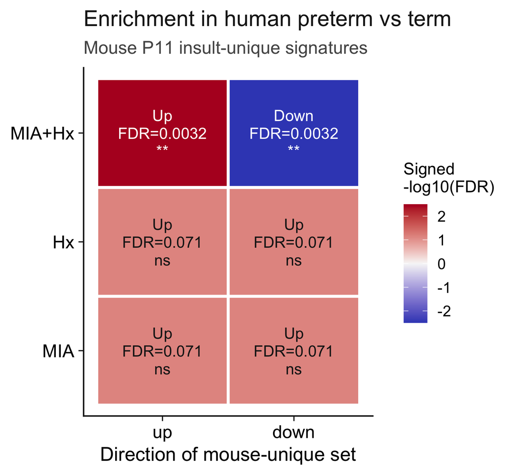

```r
plot_df <- cam_tab |>
  mutate(signed = -log10(pmax(FDR, 1e-12)) *
                  ifelse(is.na(camera_dir), 0,
                         ifelse(camera_dir == "Up", 1, -1)),
         star  = sig_star(FDR),
         label = ifelse(is.na(FDR), "n/a",
                        sprintf("%s\nFDR=%.2g\n%s", camera_dir, FDR, star)),
         Insult = factor(Insult, levels = INSULTS),
         set_direction = factor(set_direction, levels = c("up","down")))

p_hm <- ggplot(plot_df, aes(set_direction, Insult, fill = signed)) +
  geom_tile(colour = "white", linewidth = 1) +
  geom_text(aes(label = label, colour = abs(signed) > 1.8),
             size = 4.0, fontface = "plain", lineheight = 0.95) +
  scale_fill_gradient2(low = "#3b4cc0", mid = "#f7f7f7", high = "#b40426",
                        midpoint = 0, name = "Signed\n-log10(FDR)") +
  scale_colour_manual(values = c(`TRUE` = "white", `FALSE` = "#1a1a1a"),
                       guide = "none") +
  labs(title    = "Enrichment in human preterm vs term",
       subtitle = "Mouse P11 insult-unique signatures",
       x = "Direction of mouse-unique set", y = NULL) +
  theme_pub(15) +
  theme(plot.title    = element_text(face = "plain", size = 16, colour = "#1a1a1a"),
        plot.subtitle = element_text(face = "plain", size = 13),
        axis.title    = element_text(face = "plain", size = 14),
        axis.text     = element_text(face = "plain", size = 13),
        strip.text    = element_text(face = "plain", size = 13),
        legend.title  = element_text(face = "plain", size = 12),
        legend.text   = element_text(face = "plain", size = 11))

ggsave(file.path(FIG_DIR, "panelA_CAMERA_heatmap.png"),
       p_hm, width = 5.2, height = 4.8, dpi = 240)
p_hm
```

**How to read this.** Rows = insult (MIA, Hx, MIA+Hx); columns = direction of the mouse-unique set. Red = the mouse-unique set is enriched in the up-end of the human PC-vs-CC ranking; blue = enriched in the down-end. The MIA+Hx row (top) is the only one to reach significance (FDR = 0.0032, two-tailed concordant); the other four cells are not significant (FDR = 0.071), demonstrating that the cross-species enrichment is **insult-specific**, not a generic stress signature.

# 5. Panel B — MIA+Hx barcode (limma `barcodeplot` with Weight bars)

```r
mia_hx_folder <- P11_FOLDERS[[CONTRASTS[["MIA+Hx"]]]]
src <- read_rank(mia_hx_folder, CONTRASTS[["MIA+Hx"]])

iu_up <- insult_unique(M, "MIA+Hx", "up",   N_PRIMARY)
iu_dn <- insult_unique(M, "MIA+Hx", "down", N_PRIMARY)

map_with_stat <- function(mm_df) {
  mm_df$weight <- mm_df$stat
  o <- ortho[ortho$mm_stripped %in% mm_df$gene_id_stripped, ]
  o$weight <- mm_df$weight[match(o$mm_stripped, mm_df$gene_id_stripped)]
  o <- o[o$hs_stripped %in% names(hs_stat), , drop = FALSE]
  o[, c("hs_stripped", "weight")]
}
hs_up <- map_with_stat(iu_up)
hs_dn <- map_with_stat(iu_dn)

w <- numeric(length(hs_stat)); names(w) <- names(hs_stat)
w[hs_up$hs_stripped] <- hs_up$weight
w[hs_dn$hs_stripped] <- hs_dn$weight
in_set <- (names(hs_stat) %in% hs_up$hs_stripped) |
          (names(hs_stat) %in% hs_dn$hs_stripped)
w_set <- w[in_set]

out_panel_B <- file.path(FIG_DIR, "panelB_barcode_MIAandHx.png")
# Wider canvas + bigger margins so the longer side labels
# ("Down/Up in Human Preterm vs Term") render without crowding the central
# barcode, and so axis tick labels don't collide with the y-axis title.
png(out_panel_B, width = 12, height = 7, units = "in", res = 240)
# Larger top margin so we can fit (a) the band-meaning mtext labels at
# line ~0.4 and (b) the bumped-up title at line ~2.5 without collision.
par(mar = c(7, 8, 6.5, 8) + 0.1,
    cex.main = 1.55, font.main = 2,
    cex.lab  = 1.45, cex.axis = 1.30,
    mgp = c(3.8, 0.9, 0),
    family = "Arial")   # publication-wide font
limma::barcodeplot(
  statistics    = hs_stat,
  index         = in_set,
  gene.weights  = w_set,
  weights.label = "Weight",
  labels        = c("Down in Human Preterm vs Term",
                    "Up in Human Preterm vs Term"),
  main          = "",         # suppressed; re-added via mtext below at higher line
  quantiles     = quantile(hs_stat, c(0.25, 0.75)),
  col.bars      = c(COL_UP, COL_DOWN)
)
# Title bumped up to make room for the quartile-band labels below it.
mtext("P11 MIA+Hx insult-unique signature in human preterm ranking",
      side = 3, line = 2.4, cex = 1.55, font = 2)

# ---- Quartile-band labels (explain the blue / grey / pink shading) ----
# Placed in the TOP FIGURE MARGIN (below the title, above the up enrichment
# worm) — completely off the barcode plot itself. Color-matched to the bands
# beneath so the reader can map each label to its quartile.
# limma::barcodeplot uses GENE-RANK indices (1..N) as its internal x-axis,
# so we anchor at index positions N*0.14, N*0.50, N*0.86 (centres of the
# three shaded quartile bands).
N_b <- length(hs_stat)
mtext("↓ Bottom 25% (most down in PT)",
      side = 3, line = 0.4, at = N_b * 0.14,
      col = "#1e3a8a", cex = 1.05, font = 2)
mtext("Middle 50%",
      side = 3, line = 0.4, at = N_b * 0.50,
      col = "grey25",  cex = 1.05, font = 2)
mtext("↑ Top 25% (most up in PT)",
      side = 3, line = 0.4, at = N_b * 0.86,
      col = "#7f0d1a", cex = 1.05, font = 2)

# Legend in top-left — the red up-worm peaks at top-right and the blue
# down-worm peaks at bottom-left, so top-left is the cleanest empty quadrant.
# Larger cex to match the bumped-up axis font.
legend("topleft",
        legend = c("Up in mouse MIA+Hx", "Down in mouse MIA+Hx"),
        col    = c(COL_UP, COL_DOWN),
        lty    = 1, lwd = 3.2, cex = 1.20, bty = "o", bg = "white",
        inset = c(0.015, 0.015), seg.len = 2.2, y.intersp = 1.15)
invisible(dev.off())
```

```r
cat(sprintf("![](%s){width=95%%}\n\n", out_panel_B))
```

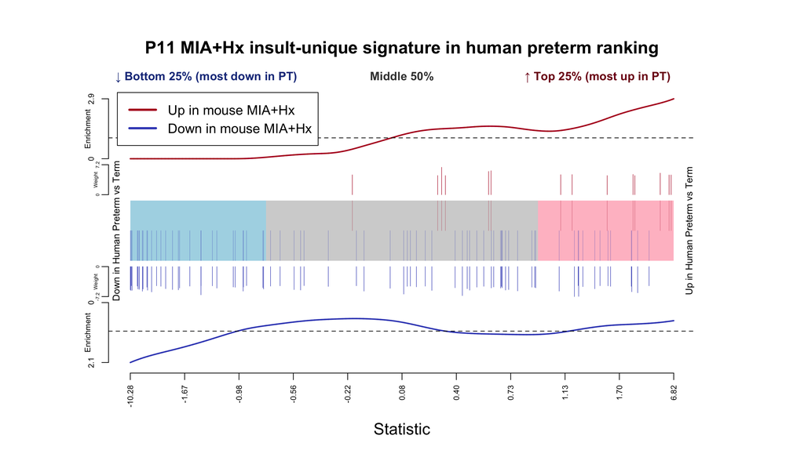

**How to read this.** Top red worm = local enrichment of the up-regulated MIA+Hx insult-unique orthologs along the human ranking; their Weight bars (mouse |Wald|) sit between the worm and the central barcode. Bottom blue worm and Weight bars do the same for the down-regulated insult-unique orthologs (note inverted axis). Central barcode: gene positions overlaid on the human ranking, with quartile-shaded background bands (left = lowest 25 % of human Wald, right = top 25 %). The up-set worm peaking at the right and the down-set worm peaking at the left is the gene-level evidence for the concordant Panel-A heatmap result.